# AlleleFlux — parallelism & divergence scores + p-value heatmaps

- Show All Code
- Hide All Code
- View Source

Author

Siddharth Uppal

Published

2026-07-24

## What this notebook is

A **dataset-generic** port of the DRIDO AlleleFlux figures (`drido/test.qmd` + `drido/significant_sites_heatmap/significant_sites_heatmap.qmd`). It builds three things from any AlleleFlux run, driven entirely by the `params` chunk below:

Every figure is drawn **once per period** (`sel_periods`, e.g. `pre_post` and `pre_end`) — periods are never combined into one faceted figure.

1. **Parallelism score** — the *within-group* (`single_sample`) score: for each MAG, the % of its sites that changed significantly **within** a group over time. Plotted as a paired box+point+line figure, one “side” per group.
2. **Divergence score** — the *between-group* score: the % of a MAG’s sites that diverge **between** treatment and control. The between-group test type is a knob (`div_test`): `two_sample_paired` (paired t-test, the default here) or `two_sample_unpaired`. This score is only interpretable against a permutation **null**, so it is drawn as **Observed vs Permuted**, and is skipped unless `permuted_run_dir` is set.
3. **p-value summary heatmaps** — MAG × (test|group) heatmaps where **cell colour = % of sites significant** (raw-p by default) and the **`*` / `**` / `***` stars = min BH-corrected q**. Rows are split and colour-barred by GTDB taxonomy.

**To retarget another dataset:** change `run_dir` (and `permuted_run_dir`, `gtdb_path`) in the `params` chunk. Everything downstream discovers timepoints, group-pairs and tests from the data.

**Score vocabulary** (AlleleFlux): *parallelism* = within-group `single_sample`; *divergence* = between-group `two_sample`. Each “score” = % of a MAG’s tested sites that are significant.

```r
# tidyverse drives the score (paired) plots; data.table + ComplexHeatmap drive the heatmaps.
# data.table is loaded FIRST so tidyverse's verbs win any name clash (we only ever call dplyr
# verbs on tibbles and data.table `[` on data.tables, so they never actually collide).
suppressPackageStartupMessages({
  library(data.table)
  library(tidyverse)
  library(ComplexHeatmap)
  library(circlize)
  library(grid)
})
```

## Parameters (the only knobs)

```r
# ===================== DATASET KNOBS — edit these to retarget ========================
# `run_dir` is a run's data-type directory (holds scores/, p_value_summary/, ...).
run_dir <- "/scratch/gpfs/AMOELLER/sidd/diet_manip/revision_July_2026/AlleleFlux_revision/AlleleFlux/longitudinal"

# GTDB taxonomy table (user_genome + classification); used for the heatmap taxonomy bar.
gtdb_path <- "/scratch/gpfs/AMOELLER/diet_manip/gtdbtk.bac120.summary.tsv"

# Permutation / null run's data-type dir, for the DIVERGENCE Observed-vs-Permuted plot.
# "" -> the divergence section is skipped with instructions on how to generate the null.
# Example once a null exists: file.path(dirname(run_dir), "permuted", "perm_42", "longitudinal")
permuted_run_dir <- ""

# Where the score-plot PNGs are written (created if absent).
fig_dir <- "/home/su2806/DietDrivenMicrobiota/Revision/AlleleFlux/notebooks/figures"

# Categorical timepoint order, used when timepoint labels are NOT numeric ages (e.g. "10mo").
# DRIDO used numeric ages (auto-ordered); the diet run uses pre/post/end (ordered by this).
timepoint_levels <- c("pre", "post", "end")

# Periods to plot. Each one gets its OWN score figure and its own heatmap — they are never
# combined into a single faceted figure. Set to character(0) for every period in the run.
sel_periods <- c("pre_post", "pre_end")

# Group pair used by the heatmap section.
sel_group_pair <- "fat_control"

# ===================== SCORE-PLOT KNOBS ===============================================
par_test <- "tTest" # parallelism: which within-group score, -> "score_<par_test>_<group> (%)"

# TEST TYPE for the between-group (divergence) comparison. AlleleFlux writes one score file per
# test kind, so this both picks the score files and names the heatmap column:
#   "two_sample_paired"   -> paired t-test (subjects matched across the two timepoints)
#   "two_sample_unpaired" -> unpaired t-test (the DRIDO reference default)
div_test <- "two_sample_paired"
div_score_col <- "score_tTest (%)" # divergence column (no group suffix); also e.g. "score_tTest_abs (%)"

# Saved-figure size (inches) for the parallelism/divergence score plots. Width grows with the
# number of timepoint panels; the in-document size is set per chunk via fig.width/fig.height.
score_fig_width_per_panel <- 9
score_fig_height <- 9

# ===================== HEATMAP KNOBS ==================================================
# Which tests become heatmap columns: parallelism (single_sample) + the divergence test chosen
# above, both t-tests. Override with an explicit vector to show more (e.g. Wilcoxon, _abs).
tests <- c("single_sample_tTest", paste0(div_test, "_tTest"))
value <- "pct_sig_p" # cell colour: raw-p % sites significant ("pct_sig_q" for FDR-based %)
tax_rank <- "phylum" # taxonomy rank for the row colour bar / grouping (rows are split by it)

# ===================== DERIVED PATHS (don't edit) =====================================
scores_mag_dir <- file.path(run_dir, "scores", "processed", "combined", "MAG")
pval_input <- file.path(
  run_dir,
  "p_value_summary",
  "significant_sites_summary",
  "significant_sites_mag_cell_stats_long.tsv"
)
dir.create(fig_dir, showWarnings = FALSE, recursive = TRUE)

cat("run_dir        :", run_dir, "\n")
```

```
run_dir        : /scratch/gpfs/AMOELLER/sidd/diet_manip/revision_July_2026/AlleleFlux_revision/AlleleFlux/longitudinal
```

```r
cat("scores_mag_dir :", scores_mag_dir, "\n")
```

```
scores_mag_dir : /scratch/gpfs/AMOELLER/sidd/diet_manip/revision_July_2026/AlleleFlux_revision/AlleleFlux/longitudinal/scores/processed/combined/MAG
```

```r
cat("div_test       :", div_test, "\n")
```

```
div_test       : two_sample_paired
```

```r
cat("heatmap tests  :", paste(tests, collapse = ", "), "\n")
```

```
heatmap tests  : single_sample_tTest, two_sample_paired_tTest
```

```r
cat(
  "sel_periods    :",
  if (length(sel_periods)) {
    paste(sel_periods, collapse = ", ")
  } else {
    "(all periods)"
  },
  "\n"
)
```

```
sel_periods    : pre_post, pre_end
```

```r
cat(
  "pval_input     :",
  pval_input,
  if (file.exists(pval_input)) " [found]" else " [MISSING]",
  "\n"
)
```

```
pval_input     : /scratch/gpfs/AMOELLER/sidd/diet_manip/revision_July_2026/AlleleFlux_revision/AlleleFlux/longitudinal/p_value_summary/significant_sites_summary/significant_sites_mag_cell_stats_long.tsv  [found]
```

```r
cat(
  "permuted_run_dir:",
  if (nzchar(permuted_run_dir)) {
    permuted_run_dir
  } else {
    "(none — divergence-vs-null skipped)"
  },
  "\n"
)
```

```
permuted_run_dir: (none — divergence-vs-null skipped)
```

## Shared timepoint ordering (generic)

DRIDO timepoints are numeric ages (`5mo_22mo`); the diet run’s are categorical (`pre_end`, `pre_post`). These helpers order **either** kind: parse a trailing number if present, else fall back to `timepoint_levels`, else alphabetical.

```r
# The later endpoint of a period: "pre_end" -> "end", "5mo_22mo" -> "22mo".
period_endpoint <- function(period) sub("^.*_", "", period)

# Rank a single timepoint label. Numeric age (last run of digits) wins; else its position in
# timepoint_levels; else NA (sorted last by order()).
tp_num <- function(label) {
  suppressWarnings(as.numeric(str_extract(label, "[0-9]+(?=[^0-9]*$)")))
}
tp_rank <- function(label) {
  n <- tp_num(label)
  ifelse(!is.na(n), n, match(label, timepoint_levels))
}

# Order a vector of PERIODS by their endpoint rank (tie-break on the start token).
tp_order <- function(periods) {
  er <- tp_rank(period_endpoint(periods))
  sr <- tp_rank(sub("_.*$", "", periods))
  if (all(is.na(er))) {
    return(sort(periods))
  }
  periods[order(er, sr)]
}
```

# Parallelism & divergence scores

Both figures are the **same plot**: for one group-pair, two “sides” per MAG, faceted by timepoint, a line linking each MAG across its two sides (coloured by whether the focal side is higher or lower). Only the data source and the words differ. (Ported verbatim from `drido/test.qmd`; only `tp_order` was generalised.)

```r
# --- ONE plot function for any paired comparison ---------------------
plot_paired_group <- function(
  df,
  pair,
  y_label,
  title_prefix,
  subtitle,
  ref_word,
  focal_word,
  hline = 5
) {
  d <- df %>%
    filter(pair_id == pair) %>%
    group_by(timepoint, MAG_ID) %>%
    filter(n_distinct(side) == 2) %>% # keep MAGs present on BOTH sides at that timepoint
    ungroup() %>%
    mutate(
      timepoint = factor(timepoint, levels = tp_order(unique(timepoint))),
      side = factor(side, levels = c("ref", "focal")),
      Group = fct_reorder(Group, as.integer(side)) # ref left, focal right
    )

  hi <- str_c("Higher in ", focal_word)
  lo <- str_c("Lower in ", focal_word)

  direction <- d %>%
    select(timepoint, MAG_ID, side, Score) %>%
    pivot_wider(names_from = side, values_from = Score) %>%
    mutate(Direction = if_else(focal >= ref, hi, lo)) %>%
    select(timepoint, MAG_ID, Direction)
  d <- left_join(d, direction, by = c("timepoint", "MAG_ID"))

  ggplot(d, aes(x = Group, y = Score)) +
    geom_hline(yintercept = hline, linetype = "dashed", linewidth = 0.6) +
    geom_line(
      aes(group = MAG_ID, color = Direction),
      alpha = 0.6,
      linewidth = 0.5
    ) +
    geom_boxplot(
      aes(fill = side),
      outlier.shape = NA,
      alpha = 0.8,
      width = 0.6
    ) +
    geom_point(
      aes(fill = side),
      shape = 21,
      color = "grey20",
      size = 2.8,
      alpha = 0.7
    ) +
    scale_fill_manual(
      values = c(ref = "grey80", focal = "#9966CC"),
      labels = c(
        ref = str_to_title(ref_word),
        focal = str_to_title(focal_word)
      ),
      name = NULL
    ) +
    scale_color_manual(
      values = setNames(c("#9966CC", "grey50"), c(hi, lo)),
      name = NULL
    ) +
    facet_wrap(vars(timepoint), scales = "free_x", nrow = 1) +
    labs(
      title = str_c(title_prefix, unique(d$comparison)),
      subtitle = subtitle,
      x = NULL,
      y = y_label
    ) +
    theme_classic(base_size = 16) +
    theme(
      legend.position = "bottom",
      legend.box = "vertical", # stack the two legends so wide labels never clip
      legend.text = element_text(size = 13),
      plot.title = element_text(hjust = 0.5, face = "bold", size = 19),
      plot.subtitle = element_text(hjust = 0.5, size = 13),
      strip.text = element_text(face = "bold", size = 15)
    )
}

# Which periods to draw, in order: `sel_periods` (if set) intersected with what's present.
periods_present <- function(available) {
  if (length(sel_periods)) {
    sel_periods[sel_periods %in% available]
  } else {
    tp_order(unique(available))
  }
}

# --- ONE driver: a SEPARATE figure per period x group-pair -----------
run_paired <- function(
  df,
  y_label,
  title_prefix,
  subtitle,
  ref_word,
  focal_word,
  file_prefix,
  save_dir = fig_dir
) {
  if (nrow(df) == 0) {
    cat("No data for this comparison — nothing to plot.\n")
    return(invisible(NULL))
  }
  periods <- periods_present(df$timepoint)
  if (length(periods) == 0) {
    cat(
      "None of sel_periods present in the score files (have: ",
      paste(sort(unique(df$timepoint)), collapse = ", "),
      ")\n",
      sep = ""
    )
    return(invisible(NULL))
  }
  plots <- list()
  for (per in periods) {
    d_per <- filter(df, timepoint == per)
    for (pair in sort(unique(d_per$pair_id))) {
      p <- plot_paired_group(
        d_per,
        pair,
        y_label,
        title_prefix,
        subtitle,
        ref_word,
        focal_word
      )
      print(p)
      key <- str_c(pair, "_", per)
      plots[[key]] <- p
      ggsave(
        file.path(save_dir, str_c(file_prefix, key, ".png")),
        p,
        width = score_fig_width_per_panel,
        height = score_fig_height,
        dpi = 300,
        limitsize = FALSE
      )
    }
  }
  invisible(plots)
}

# ================= LOADERS -> canonical long schema ==================
# Canonical schema: timepoint, pair_id, comparison, MAG_ID, side ("ref"/"focal"), Group, Score

# Parallelism: single_sample, two group-specific files per pair.
#   scores_single_sample-<period>-<groupA>_<groupB>_<focus>-MAGs.tsv
#   ref = groupB (second token), focal = the other. `test` picks score_<test>_<focus> (%).
load_parallelism <- function(dir, test = "tTest") {
  parse_one <- function(path) {
    core <- basename(path) %>%
      str_remove("^scores_single_sample-") %>%
      str_remove("-MAGs\\.tsv$")
    parts <- str_split(core, "-", simplify = TRUE) # c("<period>", "<gA>_<gB>_<focus>")
    toks <- str_split(parts[2], "_", simplify = TRUE) # c(gA, gB, focus)
    tibble(
      path = path,
      timepoint = parts[1],
      groupA = toks[1],
      groupB = toks[2],
      focus = toks[3],
      pair_id = str_c(toks[1], "_", toks[2]),
      comparison = str_c(toks[1], " vs ", toks[2])
    )
  }
  files <- list.files(
    dir,
    pattern = "^scores_single_sample-.*-MAGs\\.tsv$",
    full.names = TRUE
  )
  if (length(files) == 0) {
    return(tibble())
  }
  map_dfr(files, parse_one) %>%
    mutate(
      data = pmap(list(path, focus, groupB), function(p, f, gB) {
        df <- read_tsv(p, show_col_types = FALSE)
        sc <- str_c("score_", test, "_", f, " (%)")
        if (!sc %in% names(df)) {
          warning("No column '", sc, "' in ", basename(p))
          return(NULL)
        }
        tibble(
          MAG_ID = df[["MAG_ID"]],
          Score = df[[sc]],
          side = if_else(f == gB, "ref", "focal"),
          Group = f
        )
      })
    ) %>%
    filter(!map_lgl(data, is.null)) %>%
    select(timepoint, pair_id, comparison, data) %>%
    unnest(data)
}

# Divergence: the SAME file read from the observed vs permuted output, for whichever
# between-group test `test` names ("two_sample_paired" or "two_sample_unpaired").
#   scores_<test>-<period>-<groupA>_<groupB>-MAGs.tsv
#   ref = Permuted, focal = Observed. score_col has no group suffix, e.g. "score_tTest (%)".
load_divergence <- function(
  observed_dir,
  permuted_dir,
  score_col,
  test = "two_sample_paired"
) {
  file_re <- str_c("^scores_", test, "-.*-MAGs\\.tsv$")
  parse_one <- function(path) {
    core <- basename(path) %>%
      str_remove(str_c("^scores_", test, "-")) %>%
      str_remove("-MAGs\\.tsv$")
    parts <- str_split(core, "-", simplify = TRUE) # c("<period>", "<gA>_<gB>")
    toks <- str_split(parts[2], "_", simplify = TRUE)
    tibble(
      path = path,
      timepoint = parts[1],
      pair_id = parts[2],
      comparison = str_c(toks[1], " vs ", toks[2])
    )
  }
  read_side <- function(path, side_lbl, group_lbl) {
    df <- read_tsv(path, show_col_types = FALSE)
    if (!score_col %in% names(df)) {
      warning("No '", score_col, "' in ", basename(path))
      return(NULL)
    }
    tibble(
      MAG_ID = df[["MAG_ID"]],
      Score = df[[score_col]],
      side = side_lbl,
      Group = group_lbl
    )
  }
  files <- list.files(observed_dir, pattern = file_re, full.names = TRUE)
  if (length(files) == 0) {
    return(tibble())
  }
  map_dfr(files, parse_one) %>%
    mutate(
      data = map(path, function(p) {
        perm <- file.path(permuted_dir, basename(p))
        if (!file.exists(perm)) {
          warning("No permuted file for ", basename(p))
          return(NULL)
        }
        bind_rows(
          read_side(perm, "ref", "Permuted"),
          read_side(p, "focal", "Observed")
        )
      })
    ) %>%
    filter(!map_lgl(data, is.null)) %>%
    select(timepoint, pair_id, comparison, data) %>%
    unnest(data)
}
```

## Parallelism score (within-group)

One figure per period in `sel_periods`; the left/grey box is the reference group and the right/purple box is the focal group. A dashed line marks the 5% threshold. Score column used: `score_<par_test>_<group> (%)`.

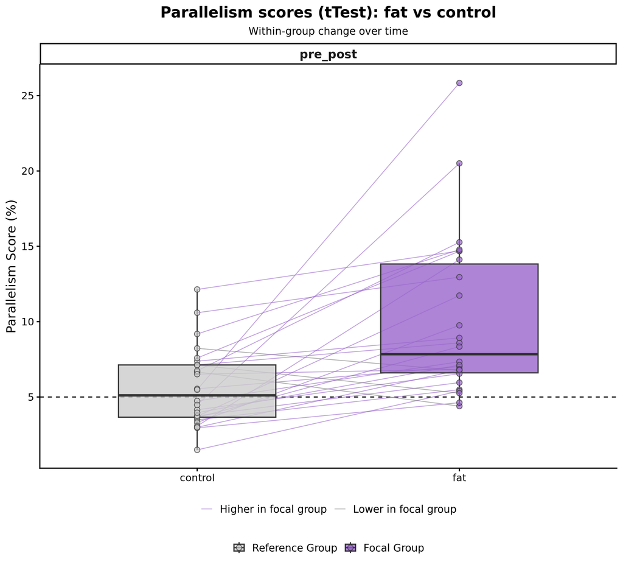

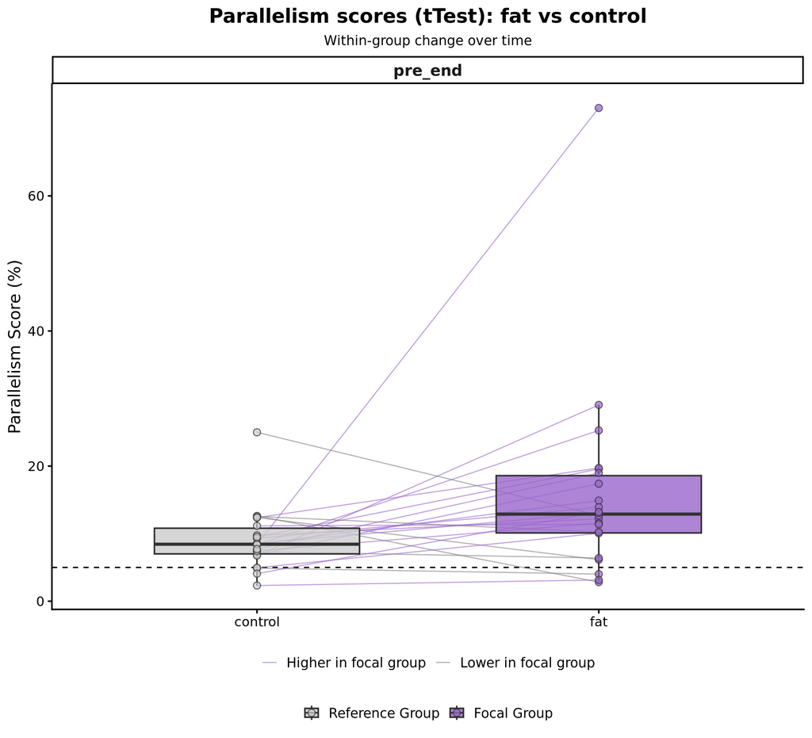

```r
par_df <- load_parallelism(scores_mag_dir, test = par_test)
if (nrow(par_df) == 0) {
  cat("No single_sample MAG score files found under:\n  ", scores_mag_dir, "\n")
} else {
  run_paired(
    par_df,
    y_label = "Parallelism Score (%)",
    title_prefix = str_c("Parallelism scores (", par_test, "): "),
    subtitle = "Within-group change over time",
    ref_word = "reference group",
    focal_word = "focal group",
    file_prefix = "parallelism_"
  )
}
```

## Divergence score (between-group, vs null)

The divergence score is only interpretable against a permutation **null**: the same `div_test` score (default `two_sample_paired`, i.e. the paired t-test) computed on label-shuffled data. This figure contrasts the **Observed** score (purple) against the **Permuted** null (grey). It renders only when `permuted_run_dir` points at a completed null run; otherwise it is skipped.

```r
if (!nzchar(permuted_run_dir)) {
  cat("Skipped: no `permuted_run_dir` set.\n")
} else {
  permuted_mag_dir <- file.path(
    permuted_run_dir,
    "scores",
    "processed",
    "combined",
    "MAG"
  )
  if (!dir.exists(permuted_mag_dir)) {
    cat(
      "Divergence-vs-null SKIPPED: permuted MAG scores dir not found:\n  ",
      permuted_mag_dir,
      "\n"
    )
  } else {
    div_df <- load_divergence(
      scores_mag_dir,
      permuted_mag_dir,
      div_score_col,
      test = div_test
    )
    if (nrow(div_df) == 0) {
      cat(
        "No matching observed/permuted ",
        div_test,
        " score files found.\n",
        sep = ""
      )
    } else {
      run_paired(
        div_df,
        y_label = str_c("Divergence Score (%) - ", div_score_col),
        title_prefix = str_c("Divergence scores (", div_test, "): "),
        subtitle = str_c(div_score_col, " - Permuted vs Observed"),
        ref_word = "permuted",
        focal_word = "observed",
        file_prefix = str_c("divergence_", div_test, "_")
      )
    }
  }
}
```

```
Skipped: no `permuted_run_dir` set.
```

# p-value summary heatmaps

**Cell colour** = `value` (% of a MAG’s sites significant; raw-p by default). **Stars** = the smallest BH-corrected `q` in that cell (`*` q<0.05, `**` q<0.01, `***` q<0.001). “Not tested” cells are grey. Input is `significant_sites_mag_cell_stats_long.tsv` from `significant_sites_summary.py`.

```r
if (!file.exists(pval_input)) {
  cat(
    "HEATMAP INPUT MISSING:\n  ",
    pval_input,
    "\n\n",
    "This table is produced automatically by the pipeline's `significant_sites_summary` rule.\n",
    "To (re)generate it manually with the packaged CLI:\n\n",
    "  alleleflux-significant-sites-summary \\\n",
    "      --input-dir ",
    file.path(run_dir, "p_value_summary"),
    " \\\n",
    "      --outdir    ",
    file.path(run_dir, "p_value_summary", "significant_sites_summary"),
    " \\\n",
    "      --q-threshold 0.05 --p-threshold 0.05 --cpus 8\n\n",
    "Then re-render. The heatmap chunks below will no-op until it exists.\n",
    sep = ""
  )
  have_pval <- FALSE
} else {
  have_pval <- TRUE
}
```

```r
# % colour scale: plasma, stretched to the LARGEST % actually observed (not a fixed 0-100),
# so the full colour range is used. Built once per figure set, hence a factory.
plasma_cols <- c(
  "#0D0887",
  "#6A00A8",
  "#B12A90",
  "#E16462",
  "#FCA636",
  "#F0F921"
)
make_pct_col <- function(max_pct) {
  hi <- if (is.finite(max_pct) && max_pct > 0) max_pct else 1
  colorRamp2(seq(0, hi, length.out = length(plasma_cols)), plasma_cols)
}
# min-q colour: bright = very significant (q~0), dark = not (q~1), fixed [0,1].
minq_col <- colorRamp2(
  c(0, 0.25, 0.5, 0.75, 1),
  c("#FDE725", "#5DC863", "#21908C", "#3B528B", "#440154")
)
# Legend titles follow whichever `value` column is being coloured.
pct_legend_title <- if (value == "pct_sig_q") {
  "% of sites\nq < 0.05"
} else {
  "% of sites\np < 0.05"
}
# Star key, drawn alongside the two colour legends.
star_legend <- Legend(
  labels = c("p < 0.001", "p < 0.01", "p < 0.05"),
  title = "Significance",
  type = "points",
  pch = c("***", "**", "*"),
  legend_gp = gpar(col = "black"),
  background = "white"
)

# Significance stars from ONE q value (scalar by design — called per cell).
q_stars <- function(q) {
  if (is.na(q)) {
    ""
  } else if (q < 0.001) {
    "***"
  } else if (q < 0.01) {
    "**"
  } else if (q < 0.05) {
    "*"
  } else {
    ""
  }
}
draw_star <- function(s, x, y, size, col = "black") {
  grid.text(s, x, y, gp = gpar(fontsize = size, col = col))
}

# Long -> wide MAG × (test|group) matrix of `value_col`. Two-sample tests (no group) get a
# label of just the test name; single-sample get "test|group". Untested MAG×col -> NA (grey).
build_matrix <- function(df, value_col) {
  df[,
    col_label := fifelse(
      is.na(group_analyzed) | group_analyzed == "",
      as.character(test_type),
      paste(test_type, group_analyzed, sep = "|")
    )
  ]
  wide <- dcast(df, mag_id ~ col_label, value.var = value_col)
  mat <- as.matrix(wide[, -1])
  rownames(mat) <- wide$mag_id
  mat
}

# Display labels for those columns: two short lines, e.g. "within\ncontrol (tTest)" and
# "between paired\n(tTest)". The matrix keeps its raw AlleleFlux names.
pretty_cols <- function(cn) {
  test <- sub("\\|.*$", "", cn)
  grp <- ifelse(grepl("\\|", cn), sub("^.*\\|", "", cn), NA_character_)
  kind <- ifelse(
    grepl("^single_sample", test),
    "within",
    ifelse(
      grepl("^two_sample_paired", test),
      "between paired",
      ifelse(grepl("^two_sample_unpaired", test), "between unpaired", test)
    )
  )
  stat <- sub(
    "^(single_sample|two_sample_paired|two_sample_unpaired)_",
    "",
    test
  )
  ifelse(
    is.na(grp),
    sprintf("%s\n(%s)", kind, stat),
    sprintf("%s %s\n(%s)", kind, grp, stat)
  )
}

# Two-panel: % (left) + min-q (right, with q-stars overlaid). Rows are NOT clustered — they are
# split and colour-barred by GTDB `tax_rank`, ordered within each taxon by total % significant.
two_panel <- function(
  mat_pct,
  mat_minq,
  title,
  pct_col,
  star_size = 8,
  star_col = "black"
) {
  tax <- tax_of(rownames(mat_pct), tax_rank)
  ord <- order(tax, -rowSums(mat_pct, na.rm = TRUE))
  mat_pct <- mat_pct[ord, , drop = FALSE]
  mat_minq <- mat_minq[ord, , drop = FALSE]
  tax <- tax[ord]
  row_split <- factor(tax, levels = names(sort(table(tax), decreasing = TRUE)))
  left_anno <- rowAnnotation(
    taxon = tax,
    col = list(taxon = make_tax_colors(tax)),
    show_annotation_name = FALSE,
    width = unit(3, "mm"),
    annotation_legend_param = list(taxon = list(title = tax_rank))
  )

  # Fixed body width per column: whatever is left over goes to the legends, so long taxon
  # names in the phylum legend are never cut off.
  body_w <- function(m) unit(27 * ncol(m), "mm")

  ht_pct <- Heatmap(
    mat_pct,
    name = value,
    col = pct_col,
    width = body_w(mat_pct),
    na_col = "grey85",
    cluster_rows = FALSE,
    cluster_columns = FALSE,
    row_split = row_split,
    left_annotation = left_anno,
    row_title = NULL, # taxon identity comes from the colour bar + its legend
    show_row_names = FALSE,
    column_labels = pretty_cols(colnames(mat_pct)),
    column_names_rot = 0,
    column_names_centered = TRUE,
    column_names_gp = gpar(fontsize = 9),
    column_title = sprintf("%s\n%% sites significant", title),
    heatmap_legend_param = list(title = pct_legend_title)
  )
  ht_minq <- Heatmap(
    mat_minq,
    name = "min q",
    col = minq_col,
    width = body_w(mat_minq),
    na_col = "grey85",
    cluster_rows = FALSE,
    cluster_columns = FALSE,
    show_row_names = FALSE,
    column_labels = pretty_cols(colnames(mat_minq)),
    column_names_rot = 0,
    column_names_centered = TRUE,
    column_names_gp = gpar(fontsize = 9),
    column_title = "Min BH-corrected p-value",
    heatmap_legend_param = list(
      title = "Min BH-corrected\np-value",
      at = seq(0, 1, 0.2)
    ),
    cell_fun = function(j, i, x, y, w, h, fill) {
      s <- q_stars(mat_minq[i, j])
      if (nzchar(s)) draw_star(s, x, y, star_size, star_col)
    }
  )
  draw(
    ht_pct + ht_minq,
    merge_legends = TRUE,
    annotation_legend_list = list(star_legend),
    padding = unit(c(2, 2, 2, 2), "mm")
  )
}
```

```r
# GTDB taxonomy -> MAG -> rank lookup.
gtdb <- fread(
  gtdb_path,
  sep = "\t",
  select = c("user_genome", "classification")
)
tax_ranks <- c(
  "domain",
  "phylum",
  "class",
  "order",
  "family",
  "genus",
  "species"
)
gtdb[, (tax_ranks) := tstrsplit(classification, ";", fixed = TRUE)]
for (r in tax_ranks) {
  gtdb[[r]] <- sub("^[a-z]__", "", gtdb[[r]])
}
setkey(gtdb, user_genome)

tax_of <- function(mags, rank = "phylum") {
  v <- gtdb[mags][[rank]]
  v[is.na(v) | v == ""] <- "Unclassified"
  v
}
make_tax_colors <- function(taxa) {
  u <- setdiff(sort(unique(taxa)), "Unclassified")
  cols <- setNames(grDevices::hcl.colors(max(length(u), 1L), "Dark 3"), u)
  c(cols, Unclassified = "grey70")
}
cat(sprintf("Loaded GTDB: %d genomes.\n", nrow(gtdb)))
```

```
Loaded GTDB: 160 genomes.
```

```r
if (have_pval) {
  df_all <- fread(pval_input, sep = "\t")
  cat(sprintf(
    "Loaded %d cell rows | comparisons: %s | group_pairs: %s | tests: %d\n",
    nrow(df_all),
    paste(sort(unique(df_all$comparison)), collapse = ", "),
    paste(sort(unique(df_all$group_pair)), collapse = ", "),
    uniqueN(df_all$test_type)
  ))
  missing_tests <- setdiff(tests, unique(df_all$test_type))
  if (length(missing_tests)) {
    warning(
      "Tests not present in data: ",
      paste(missing_tests, collapse = ", ")
    )
  }
}
```

```
Loaded 1064 cell rows | comparisons: pre_end-fat_control, pre_post-fat_control | group_pairs: fat_control | tests: 15
```

## Two panels per period (% + min-q with stars)

One figure per period in `sel_periods`, for `sel_group_pair`, restricted to `tests`. **All tested MAGs** are shown — no signal filter. Left = % sites significant, right = min BH q with significance stars. Rows are **split and colour-barred by GTDB `tax_rank`** (no clustering), and within each taxon are ordered by total % significant. The % colour scale is shared across the periods and runs from 0 to the largest % observed in any of them, so the panels are comparable.

```
pre_post: 35 MAGs shown (35 with >=1 significant site)
```

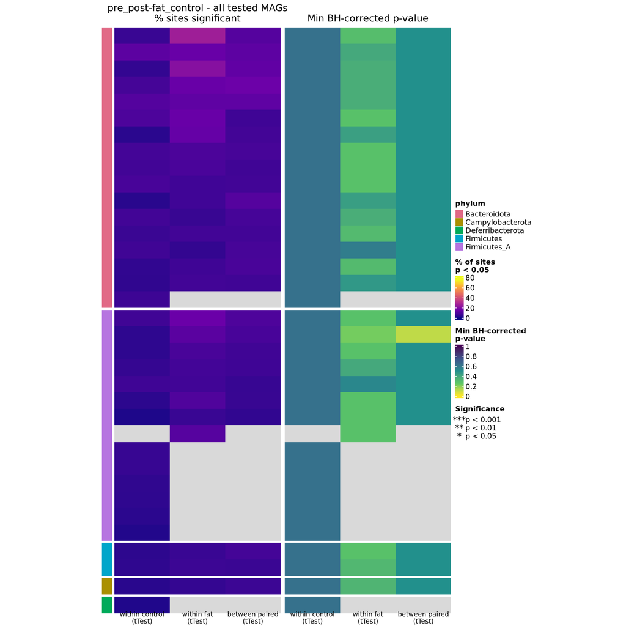

```
pre_end: 39 MAGs shown (39 with >=1 significant site)
```

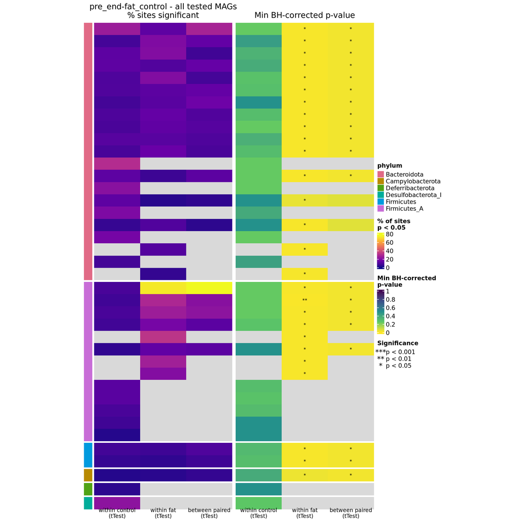

```r
if (have_pval) {
  hm_all <- df_all[group_pair == sel_group_pair & test_type %in% tests]
  hm_periods <- periods_present(hm_all$period)
  if (length(hm_periods) == 0) {
    cat(
      "No heatmap rows for group_pair =",
      sel_group_pair,
      "with tests:",
      paste(tests, collapse = ", "),
      "\n"
    )
  } else {
    # One colour scale for every period: 0 -> the largest % seen in any of them.
    pct_col <- make_pct_col(max(
      hm_all[period %in% hm_periods][[value]],
      na.rm = TRUE
    ))
    for (per in hm_periods) {
      d <- hm_all[period == per]
      mat <- build_matrix(d, value)
      mat_minq <- build_matrix(d, "min_q_value")
      # Every tested MAG is shown; MAGs with no signal simply read as 0%.
      cat(sprintf(
        "%s: %d MAGs shown (%d with >=1 significant site)\n",
        per,
        nrow(mat),
        sum(rowSums(mat > 0, na.rm = TRUE) > 0)
      ))
      two_panel(
        mat,
        mat_minq,
        sprintf("%s-%s - all tested MAGs", per, sel_group_pair),
        pct_col
      )
    }
  }
}
```